# Identifying patient groups who might benefit from personalised dosing

Thomas Weissensteiner

2024-10-08

**My scripts:**

- rendered html versions: [Rpubs/thomas-weissensteiner](https://rpubs.com/thomas-weissensteiner)
- .rmd files with executable code chunks: www.github.com/thomas-weissensteiner/portfolio/tree/main/

**About myself:** www.linkedin.com/in/ThomasWs-Mopfair

### 1. Background and motivation

Current dosing practices are based on average responses from limited clinical trials. However, overlooking variations such as to sex, age, and genetics can lead to adverse events in certain patient groups. Conversely, a new drug which might have benefit for a sub-group of patients might fail to get approval because the pivotal trial showed insufficient general efficacy in the general population.

The scripts were written for the VIS-SIG Wonderful Wednesdays challenge 10 Oct 24 ([link to recording](https://psiweb.org/vod/item/psi-vissig-wonderful-wednesday-55)). “Wonderful Wednesdays” are a monthly webinar organised by the Visualisation Special Interest Group of Statisticians in the Pharmaceutical Industry ([PSI](https://psiweb.org/)).

The task consisted of identifying patient subgroups with dose responses that deviate from the remaining study participants, and who therefore might benefit from personalized dosing.

### 2. R packages and data set

```r
# - set-up                                                     - #

library(dplyr)        # version 1.1.4  # general grammar
library(purrr)        # version 1.0.2  # set_names, list_rbind
library(tidyr)        # version 1.3.1  # pivot_longer, pivot_wider
library(ggpubr)       # version , includes ggplot2 3.4.0 # stat_compare_means, ggtexttable, ggarrange
library(kableExtra)   # rendering tables in HTML format

exampleData <- read.csv("https://raw.githubusercontent.com/VIS-SIG/Wonderful-Wednesdays/refs/heads/master/data/2024/2024-09-11/WWW54ExampleData.csv")
```

The data were a simulated dose response set with the following structure:

dose: dose levels (0, 100, 200 mg)  
target: continuous response variable (higher is better)

subgroup variables:  
bmi (body mass index: ‘low BMI’ or ‘high BMI’)  
age (‘<40 years’ or ‘≥40 years’)  
race (‘Black’, ‘Asian’, ‘White’)  
sex (‘Female’, ‘Male’)  
type (type of disease: ‘Acute disease’ or ‘Chronic disease’)

### 3. Target vs. dose in all patients

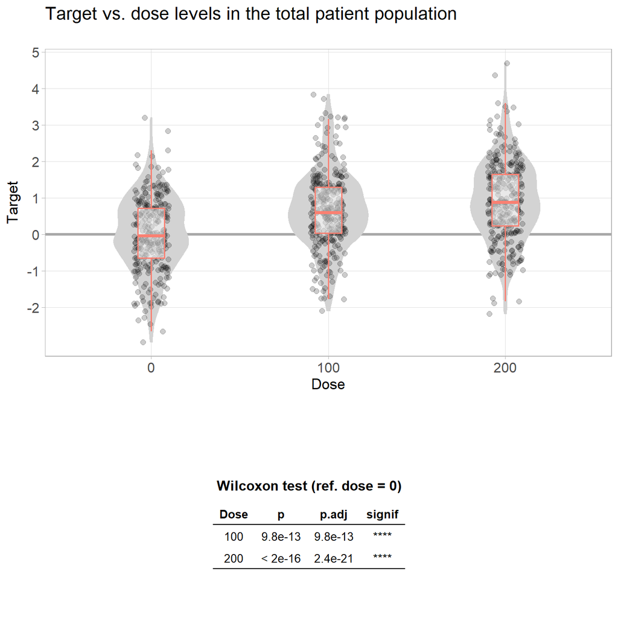

```r
# - Chunk_1                                              - #
# - Requires R-libraries and object exampleData (set-up) - #

## Plot distribution of target values at different doses in the total population

sign_test <-
  exampleData %>%
  compare_means(
  data = .,
  target ~ dose,
  ref.group = "0",
  ) %>%
  filter (
    !group1 == "100" &
    !p.signif == "ns"  ) %>%
  select("group2", "p.format", "p.adj", "p.signif")  %>%
  set_names(
    "Dose", "p", "p.adj", "signif") %>%
  ggtexttable(
    rows = NULL,
    theme = ttheme(
      "light",
      base_size = 10
      ),
    ) %>%
  tab_add_title(
    text = "Wilcoxon test (ref. dose = 0)",
    face = "bold", size = 12,
    )

# Generate split violin plot and insert the Wilcoxon test table

ggarrange(

exampleData %>%
  select (dose, target) %>%

  ggplot (
    aes(
      x= factor(
        dose,
        levels = c("0", "100", "200"
        )
      ),
      y = target)
    ) +
  geom_hline(
    yintercept = 0,
    color = "darkgrey",
    linewidth = 1.1
    ) +
  geom_violin(
    color = "lightgrey",
    fill  = "lightgrey",
    width = 0.45
    ) +
  geom_jitter(
    height = 0, width = 0.1,
    size = 2,
    alpha = 0.2
    ) +
  geom_boxplot(
    width = 0.15 ,
    outlier.shape = NA,
    color = "salmon",
    lwd = 0.7,
    alpha = 0.5
    ) +
  theme_light() +
  theme(
    text=element_text(size = 13),
    axis.text = element_text(
      size = 12),
    ) +
  scale_y_continuous(
    breaks = c(-2: 5),
    minor_breaks = NULL
    ) +
  labs(
    x = "Dose",
    y = "Target",
    size = 12, hjust = -15,
    title = "Target vs. dose levels in the total patient population\n"
    ),

# Add space between plot and table
NULL,

sign_test,

ncol = 1, nrow = 3,
heights = c(2, 0.1, 1)
)
```

The reference for the Wilcoxon test is the group of untreated patients (dose = 0). Differences in target levels in treated patients are significant. However, the distribution of target values at the three dose levels suggests that at least two subgroups might exists that could respond differently.

### 4. Best response in patient subgroups

In order to identify these potential groups, I stratified patients by one or two of the clinical and demographic characteristics that were provided. For each group, I then calculated the median response for doses 100 and 200 (difference between median target values in the treated subgroups and patients receiving a dose 0).

```r
# - Chunk_2                                              - #
# - Requires R-libraries and object exampleData (set-up) - #

## Table of responses in patient subgroups characterised by one or two variables

# Generate all pairwise combinations of patient characteristics
pVars <-
  exampleData %>%
  names() %>% .[!. %in% c("dose","target")]

pVar_pairs <-
  pVars %>%
  { c(
    lapply(., function(x) c(x, x)),       # duplicate each characteristic
    combn(.,2, simplify = F)              # all combinations of 2 characteristics
  ) }

# ---
pChar_pairs <-
  lapply(
    seq_along(pVar_pairs),
    function (x)
      exampleData %>%
      select(pVar_pairs[[x]] ) %>%
      unique(.)
    )
# ---

# Calculate median responses for the patient subgroups
response_tbl <-
  lapply(
    pVar_pairs,
    function(x)
      exampleData %>%
        group_by(
          across(all_of(x) ),
          dose
          ) %>%
      summarise(
        median(target),
        N = n()
      )
  ) %>%
  # ensure all dataframes have the same number of columns
    lapply(function(df)
      if(
        ncol(df) < length(pVars)) {
        cbind(df[, 1, drop = FALSE], df)
        }else{
          df}
      ) %>%
  lapply(function(df)
    pivot_wider(
      df,
      names_from = "dose",
      values_from = c("median(target)", "N")
      ) %>%
    set_names(
     "Var1_value", "Var2_value",
     "median_0", "median_100", "median_200",
      "N_0", "N_100", "N_200"
      )
    ) %>%
  list_rbind() %>%
  mutate(
    response_100 = median_100 - median_0,
    response_200 = median_200 - median_0,
    max_response = max(response_100, response_200) ,
    max_resp_dose = which.max(c(response_100, response_200))*100,
    N_max = c(N_100, N_200)[max_resp_dose/100]
    )


## Table of best median responses stratified by patient subgroups

# Re-order columns, sort by maximum response (highest first)
response_tbl %>%
  select(
    "Var1_value", "Var2_value",
    "N_max", "max_response",
    "N_0", "N_100", "N_200",
    "median_0", "median_100", "median_200"
    ) %>%
  arrange( desc(max_response)) %>%
  kable(., "html") %>%
  scroll_box(width = "100%", height = "200px") %>%
  kable_styling(
    bootstrap_options = c(
      "striped", "hover", "responsive", full_width = F)
    )


# Optional: rearrange so that diagonal of the plot shows responses in order of magnitude
response_tbl <-
  response_tbl %>%
  mutate(
    .before = Var1,
    Var1 = case_when (
      Var1_value %in% c("high BMI", "low BMI") ~ "BMI",
      Var1_value %in% c(">=40 years", "<40 years") ~ "Age",
      Var1_value %in% c("Asian", "Black", "White") ~ "Ethnic",
      Var1_value %in% c("Chronic disease", "Acute disease") ~ "Type",
      Var1_value %in% c("Female", "Male") ~ "Sex"
      ),
    Var2 = case_when (
      Var2_value %in% c("high BMI", "low BMI") ~ "BMI",
      Var2_value %in% c(">=40 years", "<40 years") ~ "Age",
      Var2_value %in% c("Asian", "Black", "White") ~ "Ethnic",
      Var2_value %in% c("Chronic disease", "Acute disease") ~ "Type",
      Var2_value %in% c("Female", "Male") ~ "Sex"
      )
    ) %>%
    mutate(
      pVar_equal = (Var1 == Var2)
      ) %>%
    { rbind(
        filter(., pVar_equal) %>%
          group_by(Var1) %>%
          arrange(desc(max_response), .by_group = TRUE) %>%
          mutate(max_value = max(max_response, na.rm = TRUE)) %>%
          arrange(desc(max_value)) %>%
          select (!max_value),
        filter(., !pVar_equal)
        )
      } %>%
# Add column for joining with Wilcox and Mood test results (chunks 3b and 3c)
  unite(
    Vars1_2,
    c(Var1_value, Var2_value),
    sep = "_",
    remove = F
    )
```

#### 4.1. Best responses in patients stratified by demographic and clinical parameters - showing patient numbers in treated and matched untreated subgroups

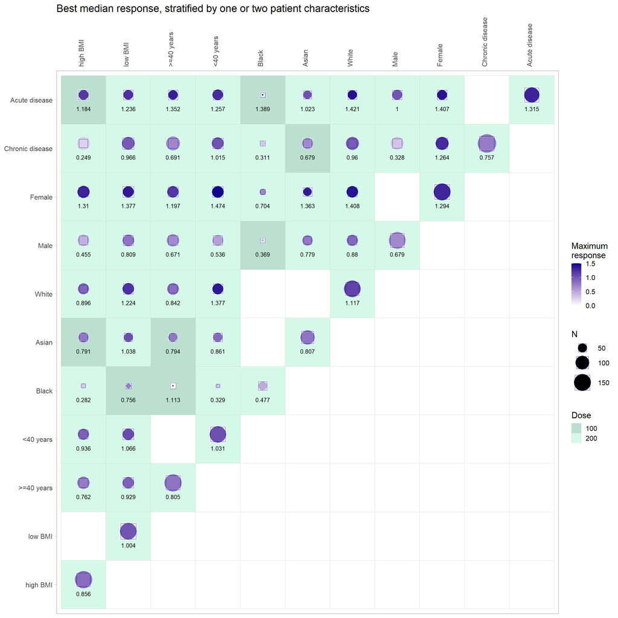

```r
# - Chunk_3a                                              - #
# - Requires R-libraries and object exampleData (set-up) - #
# - Requires object response_tbl (chunk_2)               - #


# Select and reshape

response_tbl %>%
  select(
    Var1,
    Var1_value, Var2_value,
    N_max, N_0,
    max_resp_dose, max_response
    ) %>%
  pivot_wider(
    names_from = "Var2_value",
    values_from = c(
      "max_resp_dose", "max_response", "N_max", "N_0"),
      names_sep = "-"
      ) %>%
  pivot_longer(
    cols = !c("Var1", "Var1_value"),
    names_to = c("resp", "Var2_value"),
    values_to = c("max_response"), names_sep = "-"
    ) %>%
  pivot_wider(
    names_from = "resp",
    values_from = "max_response") %>%
  mutate(
    Var1 = as.factor(Var1)
    ) %>%

# Plot data
  ggplot(
    aes(
      x = Var1_value %>%
        factor(., levels = unique(.) %>% rev ),
      y = Var2_value %>%
        factor(., levels = unique(.) %>% rev ),
      col   = max_response,
      label = max_response %>% round(3)
      )
    ) +
    geom_tile(
      aes(fill= factor(max_resp_dose)),
      col="lightgrey"
      ) +
    scale_fill_manual(
      values = c("100" = "#BBE0CF", "200" = "#D5F9E8"),
      na.translate = F
      ) +
    geom_text(
      col = "black",
      vjust = 2.5, hjust = 0.5,
      size = 10/.pt
      ) +
    geom_point(
      aes( size = N_0),
      shape = 15,
      color = "white",
      position = position_nudge(y = 0.1)
      ) +
    geom_point(
      aes( size = N_max),
      shape = 19,
      position = position_nudge(y = 0.1)
      ) +
    geom_point(
      aes( size = N_0),
      shape = 22,
      color = "darkblue",
      position = position_nudge(y = 0.1)
      ) +
    scale_size(range = c(1, 15), name = "N") +
    labs(
      x = NULL, y = NULL,
      col = "Maximum\nresponse",
      fill = "Dose",
      title = "Best median response, stratified by one or two patient characteristics") +
    scale_color_gradient2(
      low = "white", high="darkblue",
      limits = c(-0.25, 1.5)
      ) +
    scale_x_discrete(
      position = "top"
      ) +
    scale_y_discrete() +
    theme_light(base_size = 15) +
    theme(
      axis.text.x = element_text(
        angle = 90,
        vjust = 0.5,
        hjust = 0
        ),
      panel.grid = element_blank()
    )
```

```r
response_tbl %>%
  select(
    Var1, Var1_value,
    Var2, Var2_value,
    max_response, max_resp_dose, N_max,
    N_0, median_0,
    N_100, median_100,
    N_200, median_200
    ) %>%
  arrange(
    desc(max_response) ) %>%
  kable(., "html",
         caption = "Maximum response in each patient group, in descending order") %>%
    scroll_box(width = "120%", height = "150px") %>%
    kable_styling(
      font_size = 12,
      bootstrap_options = "striped"
      )
```

Maximum response in each patient group, in descending order

| Var1 | Var1_value | Var2 | Var2_value | max_response | max_resp_dose | N_max | N_0 | median_0 | N_100 | median_100 | N_200 | median_200 |
| --- | --- | --- | --- | --- | --- | --- | --- | --- | --- | --- | --- | --- |
| Age | <40 years | Sex | Female | 1.4738253 | 200 | 77 | 80 | -0.0936159 | 85 | 0.9365259 | 77 | 1.3802094 |
| Ethnic | White | Type | Acute disease | 1.4209837 | 200 | 52 | 59 | 0.1040044 | 68 | 0.6494141 | 52 | 1.5249881 |
| Ethnic | White | Sex | Female | 1.4080069 | 200 | 74 | 62 | 0.0783431 | 72 | 0.9754775 | 74 | 1.4863500 |
| Sex | Female | Type | Acute disease | 1.4073091 | 200 | 59 | 70 | 0.0783431 | 62 | 1.1145576 | 59 | 1.4856522 |
| Ethnic | Black | Type | Acute disease | 1.3886972 | 100 | 19 | 26 | -0.4210677 | 19 | 0.9676295 | 22 | 0.4197576 |
| BMI | low BMI | Sex | Female | 1.3772039 | 200 | 69 | 85 | 0.0179963 | 78 | 0.8670915 | 69 | 1.3952003 |
| Age | <40 years | Ethnic | White | 1.3769607 | 200 | 67 | 66 | -0.1072127 | 76 | 0.6428964 | 67 | 1.2697480 |
| Ethnic | Asian | Sex | Female | 1.3629210 | 200 | 45 | 60 | -0.1107637 | 50 | 0.9448312 | 45 | 1.2521573 |
| Age | >=40 years | Type | Acute disease | 1.3518500 | 200 | 55 | 68 | -0.0903008 | 60 | 0.7337059 | 55 | 1.2615492 |
| Type | Acute disease | Type | Acute disease | 1.3149731 | 200 | 120 | 135 | -0.0743407 | 129 | 0.7299124 | 120 | 1.2406324 |
| BMI | high BMI | Sex | Female | 1.3101590 | 200 | 81 | 65 | -0.0404110 | 72 | 1.1110143 | 81 | 1.2697480 |
| Sex | Female | Sex | Female | 1.2942516 | 200 | 150 | 150 | 0.0092135 | 150 | 0.9423150 | 150 | 1.3034651 |
| Sex | Female | Type | Chronic disease | 1.2642623 | 200 | 91 | 80 | -0.0349792 | 88 | 0.8593007 | 91 | 1.2292830 |
| Age | <40 years | Type | Acute disease | 1.2573735 | 200 | 65 | 67 | -0.0743407 | 69 | 0.7294408 | 65 | 1.1830328 |
| BMI | low BMI | Type | Acute disease | 1.2362381 | 200 | 57 | 68 | 0.0509698 | 71 | 0.6381219 | 57 | 1.2872080 |
| BMI | low BMI | Ethnic | White | 1.2238384 | 200 | 74 | 73 | 0.0403501 | 77 | 0.5240786 | 74 | 1.2641885 |
| Age | >=40 years | Sex | Female | 1.1970881 | 200 | 73 | 70 | 0.0430077 | 65 | 0.9744453 | 73 | 1.2400958 |
| BMI | high BMI | Type | Acute disease | 1.1837232 | 100 | 58 | 67 | -0.2336337 | 58 | 0.9500895 | 63 | 0.9350078 |
| Ethnic | White | Ethnic | White | 1.1166348 | 200 | 144 | 119 | 0.0403501 | 144 | 0.5907656 | 144 | 1.1569848 |
| Age | >=40 years | Ethnic | Black | 1.1131057 | 100 | 19 | 33 | 0.0271723 | 19 | 1.1402780 | 25 | 0.7689209 |
| BMI | low BMI | Age | <40 years | 1.0661942 | 200 | 73 | 82 | -0.1320552 | 84 | 0.5855097 | 73 | 0.9341390 |
| BMI | low BMI | Ethnic | Asian | 1.0381097 | 200 | 50 | 53 | -0.1972625 | 49 | 0.6504704 | 50 | 0.8408472 |
| Age | <40 years | Age | <40 years | 1.0314618 | 200 | 143 | 144 | -0.1032044 | 164 | 0.6061683 | 143 | 0.9282574 |
| Ethnic | Asian | Type | Acute disease | 1.0228892 | 200 | 46 | 50 | -0.1666440 | 42 | 0.8153932 | 46 | 0.8562452 |
| Age | <40 years | Type | Chronic disease | 1.0150956 | 200 | 78 | 77 | -0.1406907 | 95 | 0.5859389 | 78 | 0.8744048 |
| BMI | low BMI | BMI | low BMI | 1.0041402 | 200 | 146 | 157 | -0.0589245 | 151 | 0.5962553 | 146 | 0.9452158 |
| Sex | Male | Type | Acute disease | 1.0002103 | 200 | 61 | 65 | -0.1684336 | 67 | 0.4530151 | 61 | 0.8317767 |
| BMI | low BMI | Type | Chronic disease | 0.9663556 | 200 | 89 | 89 | -0.0895662 | 80 | 0.5915215 | 89 | 0.8767894 |
| Ethnic | White | Type | Chronic disease | 0.9598003 | 200 | 92 | 60 | -0.0663296 | 76 | 0.5824246 | 92 | 0.8934708 |
| BMI | high BMI | Age | <40 years | 0.9355423 | 200 | 70 | 62 | -0.0187840 | 80 | 0.6653357 | 70 | 0.9167583 |
| BMI | low BMI | Age | >=40 years | 0.9289176 | 200 | 73 | 75 | 0.0271723 | 67 | 0.6504704 | 73 | 0.9560899 |
| BMI | high BMI | Ethnic | White | 0.8957185 | 200 | 70 | 46 | 0.0231029 | 67 | 0.6272804 | 70 | 0.9188214 |
| Ethnic | White | Sex | Male | 0.8795431 | 200 | 70 | 57 | -0.0397959 | 72 | 0.2292620 | 70 | 0.8397472 |
| Age | <40 years | Ethnic | Asian | 0.8610026 | 200 | 53 | 56 | -0.1666440 | 59 | 0.5917255 | 53 | 0.6943586 |
| BMI | high BMI | BMI | high BMI | 0.8563161 | 200 | 154 | 123 | -0.0397959 | 149 | 0.6116301 | 154 | 0.8165202 |
| Age | >=40 years | Ethnic | White | 0.8418724 | 200 | 77 | 53 | 0.1142174 | 68 | 0.5675774 | 77 | 0.9560899 |
| BMI | low BMI | Sex | Male | 0.8092369 | 200 | 77 | 72 | -0.1148783 | 73 | 0.2511608 | 77 | 0.6943586 |
| Ethnic | Asian | Ethnic | Asian | 0.8071959 | 200 | 108 | 106 | -0.1371630 | 108 | 0.6662038 | 108 | 0.6700329 |
| Age | >=40 years | Age | >=40 years | 0.8054468 | 200 | 157 | 136 | 0.0225843 | 136 | 0.5995700 | 157 | 0.8280312 |
| Age | >=40 years | Ethnic | Asian | 0.7938925 | 100 | 49 | 50 | -0.1107637 | 49 | 0.6831288 | 55 | 0.6657136 |
| BMI | high BMI | Ethnic | Asian | 0.7914879 | 100 | 59 | 53 | -0.1083591 | 59 | 0.6831288 | 58 | 0.6097214 |
| Ethnic | Asian | Sex | Male | 0.7794252 | 200 | 63 | 46 | -0.2523170 | 58 | 0.4049125 | 63 | 0.5271082 |
| BMI | high BMI | Age | >=40 years | 0.7624675 | 200 | 84 | 61 | -0.0404110 | 69 | 0.5920707 | 84 | 0.7220564 |
| Type | Chronic disease | Type | Chronic disease | 0.7574756 | 200 | 180 | 145 | 0.0164722 | 171 | 0.5721217 | 180 | 0.7739478 |
| BMI | low BMI | Ethnic | Black | 0.7561552 | 100 | 25 | 31 | 0.1919490 | 25 | 0.9481041 | 22 | 0.4964860 |
| Ethnic | Black | Sex | Female | 0.7044310 | 200 | 31 | 28 | 0.2305768 | 28 | 0.7605207 | 31 | 0.9350078 |
| Age | >=40 years | Type | Chronic disease | 0.6906872 | 200 | 102 | 68 | 0.0495966 | 76 | 0.5632136 | 102 | 0.7402838 |
| Sex | Male | Sex | Male | 0.6787458 | 200 | 150 | 130 | -0.0819534 | 150 | 0.3836353 | 150 | 0.5967923 |
| Ethnic | Asian | Type | Chronic disease | 0.6786501 | 100 | 66 | 56 | -0.1107637 | 66 | 0.5678864 | 62 | 0.5051804 |
| Age | >=40 years | Sex | Male | 0.6711926 | 200 | 84 | 66 | -0.0212261 | 71 | 0.4517713 | 84 | 0.6499665 |
| Age | <40 years | Sex | Male | 0.5360498 | 200 | 66 | 64 | -0.1184169 | 79 | 0.2307690 | 66 | 0.4176329 |
| Ethnic | Black | Ethnic | Black | 0.4771506 | 200 | 48 | 55 | 0.2162899 | 48 | 0.5984809 | 48 | 0.6934405 |
| BMI | high BMI | Sex | Male | 0.4547091 | 200 | 73 | 58 | -0.0187840 | 77 | 0.3924904 | 73 | 0.4359251 |
| Ethnic | Black | Sex | Male | 0.3691546 | 100 | 20 | 27 | 0.2162899 | 20 | 0.5854445 | 17 | 0.2796167 |
| Age | <40 years | Ethnic | Black | 0.3291949 | 200 | 23 | 22 | 0.3089670 | 29 | 0.5962553 | 23 | 0.6381619 |
| Sex | Male | Type | Chronic disease | 0.3281991 | 200 | 89 | 65 | 0.0403501 | 83 | 0.1721311 | 89 | 0.3685491 |
| Ethnic | Black | Type | Chronic disease | 0.3114366 | 200 | 26 | 29 | 0.4957048 | 29 | 0.5701826 | 26 | 0.8071414 |
| BMI | high BMI | Ethnic | Black | 0.2817528 | 200 | 26 | 24 | 0.4770672 | 23 | 0.4165172 | 26 | 0.7588200 |
| BMI | high BMI | Type | Chronic disease | 0.2493957 | 200 | 91 | 56 | 0.4476301 | 91 | 0.5636511 | 91 | 0.6970257 |

Tiles in the plot correspond to patient groups characterised by the row and column labels. Magnitude of the maximum median response in each patient group is shown by the colour of the dots and the numerical values below them. The numbers (N) of patients in the different groups is indicated by the size of the dots (treated), and white squares with dark blue border (untreated). The dose that achieved the maximum median response is shown by the colour of the tiles (dark green: 100, lighter green: 200).

The diagonal shows groups stratified by a single characteristic, arranged so that the magnitude of the responses increases from bottom left to top right. The acute disease type was associated with the highest response, followed by female sex, and White ethnic. Conversely, patients with chronic disease, or were male or Black, had the lowest responses. BMI and age had relatively smaller effects as a single stratifier.

When two characteristics were applied, females <40 years had the highest response, followed by Whites with acute disease, White females, and females or Blacks with acute disease. The group wit the lowest median response were patients with chronic disease and high BMI. Low responses were also observed in patients who were Black and male, <40 years, with chronic disease, or high BMI. This is in contrast to the Blacks with acute disease having among the highest responses. However, numbers in these groups were relatively small and the result might need confirmation in a larger sample.

In most groups, the higher dose (200) was associated with the greater response, but Asians with chronic disease or high BMI, or patients with high BMI and acute disease might benefit more from the lower dose.

#### 4.2. Best response in patients stratified by demographic and clinical parameters - showing Wilcoxon / Mann-Whitney test p-values for difference between treated and matched untreated subroups

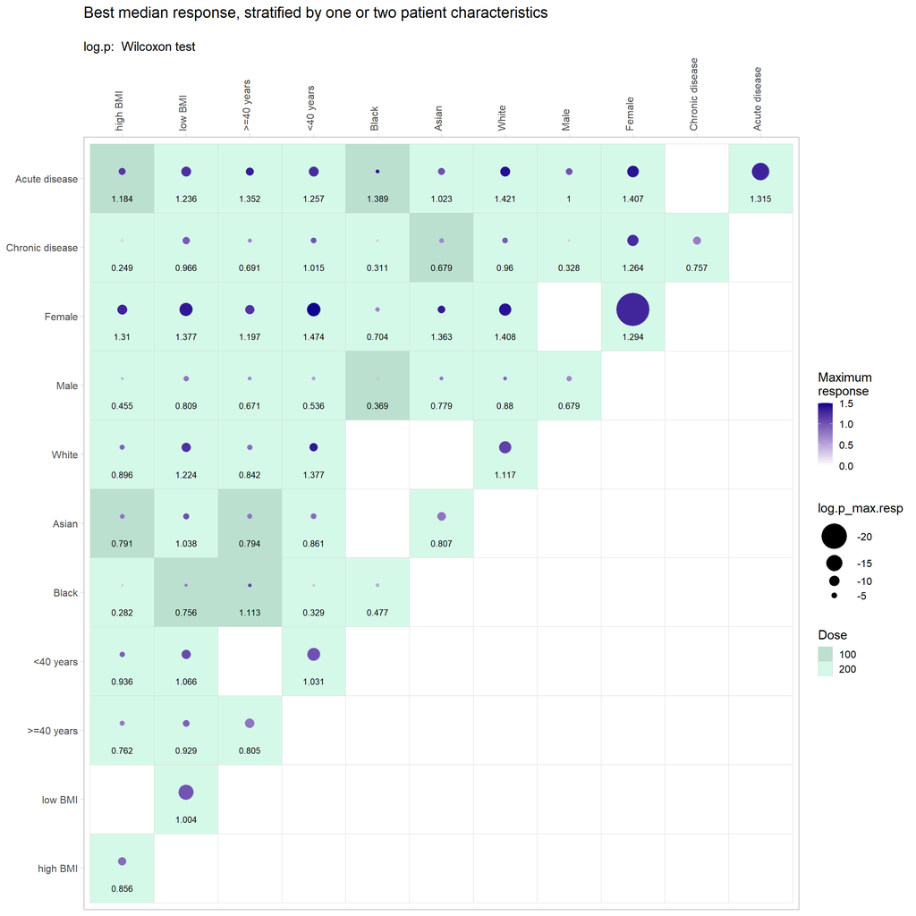

```r
# - Chunk__3b:                                      - #

## Calculate Wilcoxon test p-values for all comparisons

pTest_label <- "Wilcoxon test"

pValue.test<- function(x, y) {
  test <- wilcox.test(x, y)
  return(test$p.value)
}

# - Chunk__pTests: common code for p-value calculations in chunks 3b and c - #
# - Requires R-libraries and object exampleData (set-up)                   - #
# - Requires objects pChar_pairs and response_tbl (chunk_2)                - #


pValue.test_results <- list ()

for (i in 1: length(pChar_pairs)) {
  pValue.test_results_j <- list()

  for (j in 1: nrow(pChar_pairs[[i]])) {
    x <- pChar_pairs[[i]] %>% names
    y <- pChar_pairs[[i]] %>% .[j, ]%>% set_names(x)
# Ensure names are preserved when cbinding as transformed dataframe below
    if (length(x) == 1) {
      y <- as.data.frame (t(y))
      }

  pValue.test_results_j[[j]] <-
    exampleData %>%
      {if (length(x) == 1) {
        filter(.,
          get(x[1]) == paste(y[1])
          )
        } else {
          filter(.,
            get(x[1]) == paste(y[1]) &
            get(x[2]) == paste(y[2])
            )
          }
        } %>%
      summarise(
        p_value_0_vs_100 = pValue.test(target[dose == "0"], target[dose == "100"] ),
        p_value_0_vs_200 = pValue.test(target[dose == "0"], target[dose == "200"] )
        ) %>%
      cbind(y, .)
    }
    pValue.test_results[[i]] <- pValue.test_results_j

  }

pValue.test_results <-
pValue.test_results %>%
  flatten() %>%
  lapply(function(df)
      if(
        ncol(df) < 4) {
        cbind(df[, 1, drop = FALSE], df)
        }else{
          df}
      ) %>%
    lapply(function(df)
      set_names(df,
        "Var1_value", "Var2_value",
        "p_value_0_vs_100", "p_value_0_vs_200"
        )
      ) %>%
    list_rbind() %>%
    mutate(
      log.p_100 = log10(p_value_0_vs_100) %>% round(digits = 2),
      log.p_200 = log10(p_value_0_vs_200) %>% round(digits = 2)
    ) %>%
    select(
      !c(p_value_0_vs_100, p_value_0_vs_200)
    ) %>%
# Add column for joining with response_tbl and join
    unite(
      Vars1_2,
      c(Var1_value, Var2_value),
      sep = "_",
      remove = F
      ) %>%
  left_join(
    response_tbl, .) %>%
  mutate(
     log.p_max.resp = case_when(
      max_resp_dose == "100" ~ log.p_100,
      max_resp_dose == "200" ~ log.p_200
     )
    )


 ## Generate new plot of best responses, showing Wilcoxon p-values

pValue.test_results %>%
# Select and reshape
  select(
    Var1_value, Var2_value,
    log.p_max.resp,
    max_resp_dose, max_response
    ) %>%
  pivot_wider(
    names_from = "Var2_value",
    values_from = c(
      "max_resp_dose", "max_response", "log.p_max.resp"),
      names_sep = "-"
      ) %>%
  pivot_longer(
    cols = !c("Var1", "Var1_value"),
    names_to = c("resp", "Var2_value"),
    values_to = c("max_response"), names_sep = "-"
    ) %>%
  pivot_wider(
    names_from = "resp",
    values_from = "max_response") %>%
  mutate(
    Var1_value = as.factor(Var1_value)
    ) %>%

# Plot data
  ggplot(
    aes(
      x = Var1_value %>%
        factor(.,
          levels = unique(.) %>% rev()
          ),
      y = Var2_value %>%
        factor(.,
          levels = unique(.) %>% rev()
          ),
      col   = max_response,
      label = max_response %>% round(3)
      )
    ) +
    geom_tile(
      aes(fill= factor(max_resp_dose)),
      col="lightgrey"
      ) +
    scale_fill_manual(
      values = c("100" = "#BBE0CF", "200" = "#D5F9E8"),
      na.translate = F
      ) +
    geom_text(
      col = "black",
      vjust = 3.5, hjust = 0.5,
      size = 10/.pt
      ) +
    geom_point(
      aes( size = log.p_max.resp),
      shape = 19,
      position = position_nudge(y = 0.1)
      ) +
    scale_size(
      range = c(18, 1),
      name = "log.p_max.resp") +
    labs(
      x = NULL, y = NULL,
      col = "Maximum\nresponse",
      fill = "Dose",
      title = "Best median response, stratified by one or two patient characteristics",
      subtitle = paste( "\nlog.p: ", pTest_label)
      ) +
    scale_color_gradient2(
      low = "white", high="darkblue",
      limits = c(-0.25, 1.5)
      ) +
    scale_x_discrete(
      position = "top"
      ) +
    scale_y_discrete() +
    theme_light(base_size = 15) +
    theme(
      axis.text.x = element_text(
        angle = 90,
        vjust = 0.5,
        hjust = 0
        ),
      panel.grid = element_blank()
      )
```

```r
# Display, sorted by significance of response at dose 200

pValue.test_results %>%
  select(
    Var1, Var1_value,
    Var2, Var2_value,
    log.p_max.resp,
    max_response, max_resp_dose,
    N_100, median_100,
    N_200, median_200
    ) %>%
  arrange(log.p_max.resp) %>%
  kable(., "html",
        caption = "Maximum responses, sorted by significance") %>%
    scroll_box(width = "120%", height = "150px") %>%
    kable_styling(
      font_size = 12,
      bootstrap_options = "striped"
      )
```

Maximum responses, sorted by significance

| Var1 | Var1_value | Var2 | Var2_value | log.p_max.resp | max_response | max_resp_dose | N_100 | median_100 | N_200 | median_200 |
| --- | --- | --- | --- | --- | --- | --- | --- | --- | --- | --- |
| Sex | Female | Sex | Female | -21.33 | 1.2942516 | 200 | 150 | 0.9423150 | 150 | 1.3034651 |
| Type | Acute disease | Type | Acute disease | -15.94 | 1.3149731 | 200 | 129 | 0.7299124 | 120 | 1.2406324 |
| BMI | low BMI | BMI | low BMI | -14.33 | 1.0041402 | 200 | 151 | 0.5962553 | 146 | 0.9452158 |
| Age | <40 years | Sex | Female | -13.00 | 1.4738253 | 200 | 85 | 0.9365259 | 77 | 1.3802094 |
| BMI | low BMI | Sex | Female | -12.67 | 1.3772039 | 200 | 78 | 0.8670915 | 69 | 1.3952003 |
| Age | <40 years | Age | <40 years | -12.35 | 1.0314618 | 200 | 164 | 0.6061683 | 143 | 0.9282574 |
| Ethnic | White | Ethnic | White | -12.00 | 1.1166348 | 200 | 144 | 0.5907656 | 144 | 1.1569848 |
| Ethnic | White | Sex | Female | -11.93 | 1.4080069 | 200 | 72 | 0.9754775 | 74 | 1.4863500 |
| Sex | Female | Type | Acute disease | -11.41 | 1.4073091 | 200 | 62 | 1.1145576 | 59 | 1.4856522 |
| Sex | Female | Type | Chronic disease | -10.93 | 1.2642623 | 200 | 88 | 0.8593007 | 91 | 1.2292830 |
| Ethnic | White | Type | Acute disease | -9.57 | 1.4209837 | 200 | 68 | 0.6494141 | 52 | 1.5249881 |
| BMI | high BMI | Sex | Female | -9.39 | 1.3101590 | 200 | 72 | 1.1110143 | 81 | 1.2697480 |
| BMI | low BMI | Type | Acute disease | -9.37 | 1.2362381 | 200 | 71 | 0.6381219 | 57 | 1.2872080 |
| Age | <40 years | Type | Acute disease | -9.30 | 1.2573735 | 200 | 69 | 0.7294408 | 65 | 1.1830328 |
| Age | >=40 years | Age | >=40 years | -9.08 | 0.8054468 | 200 | 136 | 0.5995700 | 157 | 0.8280312 |
| Age | >=40 years | Sex | Female | -8.89 | 1.1970881 | 200 | 65 | 0.9744453 | 73 | 1.2400958 |
| BMI | low BMI | Age | <40 years | -8.82 | 1.0661942 | 200 | 84 | 0.5855097 | 73 | 0.9341390 |
| BMI | low BMI | Ethnic | White | -8.82 | 1.2238384 | 200 | 77 | 0.5240786 | 74 | 1.2641885 |
| Ethnic | Asian | Ethnic | Asian | -7.93 | 0.8071959 | 200 | 108 | 0.6662038 | 108 | 0.6700329 |
| BMI | high BMI | BMI | high BMI | -7.75 | 0.8563161 | 200 | 149 | 0.6116301 | 154 | 0.8165202 |
| Age | <40 years | Ethnic | White | -7.66 | 1.3769607 | 200 | 76 | 0.6428964 | 67 | 1.2697480 |
| Type | Chronic disease | Type | Chronic disease | -7.50 | 0.7574756 | 200 | 171 | 0.5721217 | 180 | 0.7739478 |
| Age | >=40 years | Type | Acute disease | -7.36 | 1.3518500 | 200 | 60 | 0.7337059 | 55 | 1.2615492 |
| Ethnic | Asian | Sex | Female | -7.11 | 1.3629210 | 200 | 50 | 0.9448312 | 45 | 1.2521573 |
| BMI | low BMI | Type | Chronic disease | -6.64 | 0.9663556 | 200 | 80 | 0.5915215 | 89 | 0.8767894 |
| Ethnic | Asian | Type | Acute disease | -6.50 | 1.0228892 | 200 | 42 | 0.8153932 | 46 | 0.8562452 |
| BMI | high BMI | Type | Acute disease | -6.36 | 1.1837232 | 100 | 58 | 0.9500895 | 63 | 0.9350078 |
| Sex | Male | Type | Acute disease | -6.14 | 1.0002103 | 200 | 67 | 0.4530151 | 61 | 0.8317767 |
| BMI | low BMI | Age | >=40 years | -6.05 | 0.9289176 | 200 | 67 | 0.6504704 | 73 | 0.9560899 |
| BMI | low BMI | Ethnic | Asian | -5.39 | 1.0381097 | 200 | 49 | 0.6504704 | 50 | 0.8408472 |
| Ethnic | White | Type | Chronic disease | -5.02 | 0.9598003 | 200 | 76 | 0.5824246 | 92 | 0.8934708 |
| Age | <40 years | Ethnic | Asian | -4.94 | 0.8610026 | 200 | 59 | 0.5917255 | 53 | 0.6943586 |
| Age | <40 years | Type | Chronic disease | -4.66 | 1.0150956 | 200 | 95 | 0.5859389 | 78 | 0.8744048 |
| Age | >=40 years | Ethnic | White | -4.56 | 0.8418724 | 200 | 68 | 0.5675774 | 77 | 0.9560899 |
| Sex | Male | Sex | Male | -4.45 | 0.6787458 | 200 | 150 | 0.3836353 | 150 | 0.5967923 |
| BMI | low BMI | Sex | Male | -4.34 | 0.8092369 | 200 | 73 | 0.2511608 | 77 | 0.6943586 |
| BMI | high BMI | Age | <40 years | -4.31 | 0.9355423 | 200 | 80 | 0.6653357 | 70 | 0.9167583 |
| Age | >=40 years | Ethnic | Asian | -4.25 | 0.7938925 | 100 | 49 | 0.6831288 | 55 | 0.6657136 |
| BMI | high BMI | Ethnic | White | -4.16 | 0.8957185 | 200 | 67 | 0.6272804 | 70 | 0.9188214 |
| BMI | high BMI | Age | >=40 years | -4.12 | 0.7624675 | 200 | 69 | 0.5920707 | 84 | 0.7220564 |
| Ethnic | Asian | Type | Chronic disease | -3.63 | 0.6786501 | 100 | 66 | 0.5678864 | 62 | 0.5051804 |
| BMI | high BMI | Ethnic | Asian | -3.61 | 0.7914879 | 100 | 59 | 0.6831288 | 58 | 0.6097214 |
| Ethnic | Black | Sex | Female | -3.08 | 0.7044310 | 200 | 28 | 0.7605207 | 31 | 0.9350078 |
| Age | >=40 years | Type | Chronic disease | -2.98 | 0.6906872 | 200 | 76 | 0.5632136 | 102 | 0.7402838 |
| Ethnic | White | Sex | Male | -2.64 | 0.8795431 | 200 | 72 | 0.2292620 | 70 | 0.8397472 |
| Ethnic | Asian | Sex | Male | -2.50 | 0.7794252 | 200 | 58 | 0.4049125 | 63 | 0.5271082 |
| Age | >=40 years | Sex | Male | -2.42 | 0.6711926 | 200 | 71 | 0.4517713 | 84 | 0.6499665 |
| Ethnic | Black | Ethnic | Black | -2.39 | 0.4771506 | 200 | 48 | 0.5984809 | 48 | 0.6934405 |
| Ethnic | Black | Type | Acute disease | -2.35 | 1.3886972 | 100 | 19 | 0.9676295 | 22 | 0.4197576 |
| Age | <40 years | Sex | Male | -2.29 | 0.5360498 | 200 | 79 | 0.2307690 | 66 | 0.4176329 |
| Age | >=40 years | Ethnic | Black | -1.98 | 1.1131057 | 100 | 19 | 1.1402780 | 25 | 0.7689209 |
| BMI | low BMI | Ethnic | Black | -1.76 | 0.7561552 | 100 | 25 | 0.9481041 | 22 | 0.4964860 |
| BMI | high BMI | Type | Chronic disease | -1.69 | 0.2493957 | 200 | 91 | 0.5636511 | 91 | 0.6970257 |
| BMI | high BMI | Ethnic | Black | -1.26 | 0.2817528 | 200 | 23 | 0.4165172 | 26 | 0.7588200 |
| Age | <40 years | Ethnic | Black | -1.26 | 0.3291949 | 200 | 29 | 0.5962553 | 23 | 0.6381619 |
| Ethnic | Black | Sex | Male | -1.12 | 0.3691546 | 100 | 20 | 0.5854445 | 17 | 0.2796167 |
| BMI | high BMI | Sex | Male | -1.09 | 0.4547091 | 200 | 77 | 0.3924904 | 73 | 0.4359251 |
| Ethnic | Black | Type | Chronic disease | -0.75 | 0.3114366 | 200 | 29 | 0.5701826 | 26 | 0.8071414 |
| Sex | Male | Type | Chronic disease | -0.62 | 0.3281991 | 200 | 83 | 0.1721311 | 89 | 0.3685491 |

#### 4.3. Best response in patients stratified by demographic and clinical parameters - showing Mood test p-values for difference between treated and matched untreated subroups

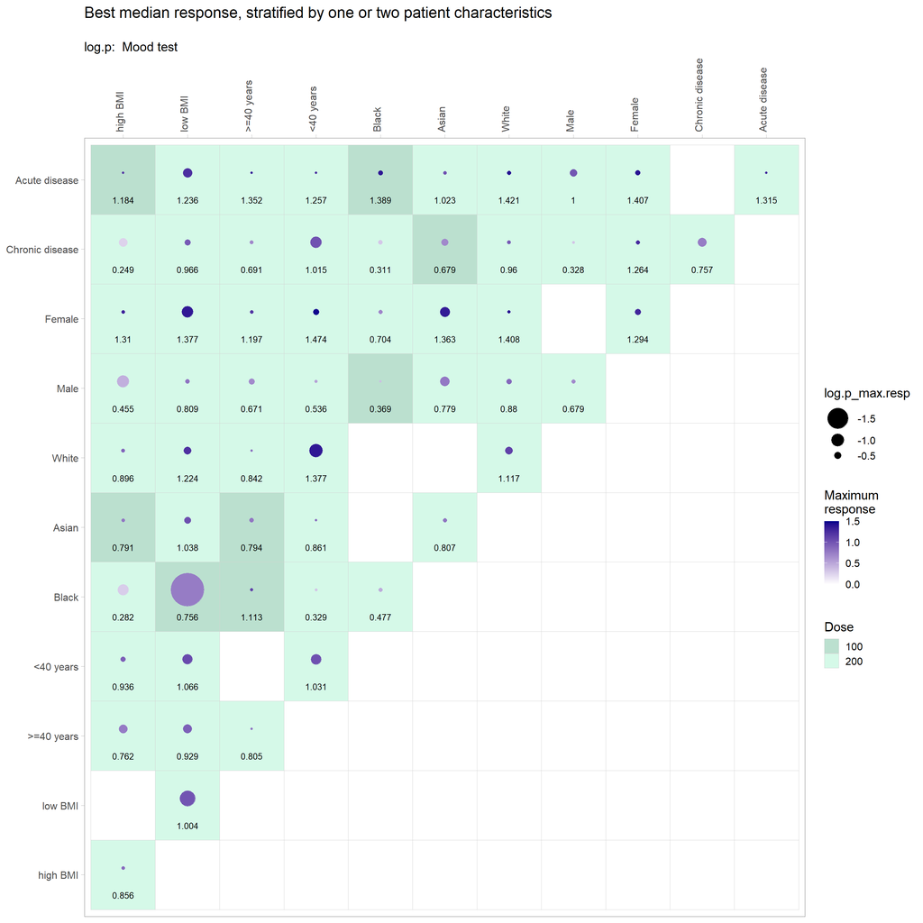

```r
# - Chunk__3c:                                      - #

## Calculate Mood test p-values for all comparisons

pTest_label <- "Mood test"

pValue.test<- function(x, y) {
  test <- mood.test(x, y)
  return(test$p.value)
}

# - Chunk__pTests: common code for p-value calculations in chunks 3b and c - #
# - Requires R-libraries and object exampleData (set-up)                   - #
# - Requires objects pChar_pairs and response_tbl (chunk_2)                - #


pValue.test_results <- list ()

for (i in 1: length(pChar_pairs)) {
  pValue.test_results_j <- list()

  for (j in 1: nrow(pChar_pairs[[i]])) {
    x <- pChar_pairs[[i]] %>% names
    y <- pChar_pairs[[i]] %>% .[j, ]%>% set_names(x)
# Ensure names are preserved when cbinding as transformed dataframe below
    if (length(x) == 1) {
      y <- as.data.frame (t(y))
      }

  pValue.test_results_j[[j]] <-
    exampleData %>%
      {if (length(x) == 1) {
        filter(.,
          get(x[1]) == paste(y[1])
          )
        } else {
          filter(.,
            get(x[1]) == paste(y[1]) &
            get(x[2]) == paste(y[2])
            )
          }
        } %>%
      summarise(
        p_value_0_vs_100 = pValue.test(target[dose == "0"], target[dose == "100"] ),
        p_value_0_vs_200 = pValue.test(target[dose == "0"], target[dose == "200"] )
        ) %>%
      cbind(y, .)
    }
    pValue.test_results[[i]] <- pValue.test_results_j

  }

pValue.test_results <-
pValue.test_results %>%
  flatten() %>%
  lapply(function(df)
      if(
        ncol(df) < 4) {
        cbind(df[, 1, drop = FALSE], df)
        }else{
          df}
      ) %>%
    lapply(function(df)
      set_names(df,
        "Var1_value", "Var2_value",
        "p_value_0_vs_100", "p_value_0_vs_200"
        )
      ) %>%
    list_rbind() %>%
    mutate(
      log.p_100 = log10(p_value_0_vs_100) %>% round(digits = 2),
      log.p_200 = log10(p_value_0_vs_200) %>% round(digits = 2)
    ) %>%
    select(
      !c(p_value_0_vs_100, p_value_0_vs_200)
    ) %>%
# Add column for joining with response_tbl and join
    unite(
      Vars1_2,
      c(Var1_value, Var2_value),
      sep = "_",
      remove = F
      ) %>%
  left_join(
    response_tbl, .) %>%
  mutate(
     log.p_max.resp = case_when(
      max_resp_dose == "100" ~ log.p_100,
      max_resp_dose == "200" ~ log.p_200
     )
    )


 ## Generate new plot of best responses, showing Wilcoxon p-values

pValue.test_results %>%
# Select and reshape
  select(
    Var1_value, Var2_value,
    log.p_max.resp,
    max_resp_dose, max_response
    ) %>%
  pivot_wider(
    names_from = "Var2_value",
    values_from = c(
      "max_resp_dose", "max_response", "log.p_max.resp"),
      names_sep = "-"
      ) %>%
  pivot_longer(
    cols = !c("Var1", "Var1_value"),
    names_to = c("resp", "Var2_value"),
    values_to = c("max_response"), names_sep = "-"
    ) %>%
  pivot_wider(
    names_from = "resp",
    values_from = "max_response") %>%
  mutate(
    Var1_value = as.factor(Var1_value)
    ) %>%

# Plot data
  ggplot(
    aes(
      x = Var1_value %>%
        factor(.,
          levels = unique(.) %>% rev()
          ),
      y = Var2_value %>%
        factor(.,
          levels = unique(.) %>% rev()
          ),
      col   = max_response,
      label = max_response %>% round(3)
      )
    ) +
    geom_tile(
      aes(fill= factor(max_resp_dose)),
      col="lightgrey"
      ) +
    scale_fill_manual(
      values = c("100" = "#BBE0CF", "200" = "#D5F9E8"),
      na.translate = F
      ) +
    geom_text(
      col = "black",
      vjust = 3.5, hjust = 0.5,
      size = 10/.pt
      ) +
    geom_point(
      aes( size = log.p_max.resp),
      shape = 19,
      position = position_nudge(y = 0.1)
      ) +
    scale_size(
      range = c(18, 1),
      name = "log.p_max.resp") +
    labs(
      x = NULL, y = NULL,
      col = "Maximum\nresponse",
      fill = "Dose",
      title = "Best median response, stratified by one or two patient characteristics",
      subtitle = paste( "\nlog.p: ", pTest_label)
      ) +
    scale_color_gradient2(
      low = "white", high="darkblue",
      limits = c(-0.25, 1.5)
      ) +
    scale_x_discrete(
      position = "top"
      ) +
    scale_y_discrete() +
    theme_light(base_size = 15) +
    theme(
      axis.text.x = element_text(
        angle = 90,
        vjust = 0.5,
        hjust = 0
        ),
      panel.grid = element_blank()
      )
```

```r
# Display, sorted by significance of response at dose 200

pValue.test_results %>%
  select(
    Var1, Var1_value,
    Var2, Var2_value,
    log.p_max.resp,
    max_response, max_resp_dose,
    N_100, median_100,
    N_200, median_200
    ) %>%
  arrange(log.p_max.resp) %>%
  kable(., "html",
        caption = "Maximum responses, sorted by significance") %>%
    scroll_box(width = "120%", height = "150px") %>%
    kable_styling(
      font_size = 12,
      bootstrap_options = "striped"
      )
```

Maximum responses, sorted by significance

| Var1 | Var1_value | Var2 | Var2_value | log.p_max.resp | max_response | max_resp_dose | N_100 | median_100 | N_200 | median_200 |
| --- | --- | --- | --- | --- | --- | --- | --- | --- | --- | --- |
| BMI | low BMI | Ethnic | Black | -1.79 | 0.7561552 | 100 | 25 | 0.9481041 | 22 | 0.4964860 |
| BMI | low BMI | BMI | low BMI | -1.20 | 1.0041402 | 200 | 151 | 0.5962553 | 146 | 0.9452158 |
| Age | <40 years | Ethnic | White | -1.06 | 1.3769607 | 200 | 76 | 0.6428964 | 67 | 1.2697480 |
| BMI | high BMI | Sex | Male | -0.95 | 0.4547091 | 200 | 77 | 0.3924904 | 73 | 0.4359251 |
| BMI | low BMI | Sex | Female | -0.90 | 1.3772039 | 200 | 78 | 0.8670915 | 69 | 1.3952003 |
| Age | <40 years | Type | Chronic disease | -0.90 | 1.0150956 | 200 | 95 | 0.5859389 | 78 | 0.8744048 |
| BMI | high BMI | Ethnic | Black | -0.88 | 0.2817528 | 200 | 23 | 0.4165172 | 26 | 0.7588200 |
| Age | <40 years | Age | <40 years | -0.81 | 1.0314618 | 200 | 164 | 0.6061683 | 143 | 0.9282574 |
| BMI | low BMI | Age | <40 years | -0.80 | 1.0661942 | 200 | 84 | 0.5855097 | 73 | 0.9341390 |
| Ethnic | Asian | Sex | Female | -0.77 | 1.3629210 | 200 | 50 | 0.9448312 | 45 | 1.2521573 |
| Ethnic | Asian | Sex | Male | -0.75 | 0.7794252 | 200 | 58 | 0.4049125 | 63 | 0.5271082 |
| BMI | low BMI | Type | Acute disease | -0.70 | 1.2362381 | 200 | 71 | 0.6381219 | 57 | 1.2872080 |
| Type | Chronic disease | Type | Chronic disease | -0.67 | 0.7574756 | 200 | 171 | 0.5721217 | 180 | 0.7739478 |
| BMI | low BMI | Age | >=40 years | -0.67 | 0.9289176 | 200 | 67 | 0.6504704 | 73 | 0.9560899 |
| BMI | high BMI | Type | Chronic disease | -0.65 | 0.2493957 | 200 | 91 | 0.5636511 | 91 | 0.6970257 |
| BMI | high BMI | Age | >=40 years | -0.64 | 0.7624675 | 200 | 69 | 0.5920707 | 84 | 0.7220564 |
| Ethnic | White | Ethnic | White | -0.55 | 1.1166348 | 200 | 144 | 0.5907656 | 144 | 1.1569848 |
| BMI | low BMI | Ethnic | White | -0.55 | 1.2238384 | 200 | 77 | 0.5240786 | 74 | 1.2641885 |
| Sex | Male | Type | Acute disease | -0.52 | 1.0002103 | 200 | 67 | 0.4530151 | 61 | 0.8317767 |
| Ethnic | Asian | Type | Chronic disease | -0.50 | 0.6786501 | 100 | 66 | 0.5678864 | 62 | 0.5051804 |
| BMI | low BMI | Ethnic | Asian | -0.46 | 1.0381097 | 200 | 49 | 0.6504704 | 50 | 0.8408472 |
| BMI | low BMI | Type | Chronic disease | -0.42 | 0.9663556 | 200 | 80 | 0.5915215 | 89 | 0.8767894 |
| Age | >=40 years | Sex | Male | -0.42 | 0.6711926 | 200 | 71 | 0.4517713 | 84 | 0.6499665 |
| Age | <40 years | Sex | Female | -0.41 | 1.4738253 | 200 | 85 | 0.9365259 | 77 | 1.3802094 |
| Sex | Female | Sex | Female | -0.39 | 1.2942516 | 200 | 150 | 0.9423150 | 150 | 1.3034651 |
| Ethnic | White | Sex | Male | -0.33 | 0.8795431 | 200 | 72 | 0.2292620 | 70 | 0.8397472 |
| BMI | high BMI | Age | <40 years | -0.29 | 0.9355423 | 200 | 80 | 0.6653357 | 70 | 0.9167583 |
| Sex | Female | Type | Acute disease | -0.29 | 1.4073091 | 200 | 62 | 1.1145576 | 59 | 1.4856522 |
| Ethnic | Black | Type | Acute disease | -0.26 | 1.3886972 | 100 | 19 | 0.9676295 | 22 | 0.4197576 |
| Age | >=40 years | Ethnic | Asian | -0.25 | 0.7938925 | 100 | 49 | 0.6831288 | 55 | 0.6657136 |
| BMI | low BMI | Sex | Male | -0.24 | 0.8092369 | 200 | 73 | 0.2511608 | 77 | 0.6943586 |
| Ethnic | Black | Type | Chronic disease | -0.23 | 0.3114366 | 200 | 29 | 0.5701826 | 26 | 0.8071414 |
| Sex | Female | Type | Chronic disease | -0.22 | 1.2642623 | 200 | 88 | 0.8593007 | 91 | 1.2292830 |
| Sex | Male | Sex | Male | -0.21 | 0.6787458 | 200 | 150 | 0.3836353 | 150 | 0.5967923 |
| Ethnic | Black | Sex | Female | -0.21 | 0.7044310 | 200 | 28 | 0.7605207 | 31 | 0.9350078 |
| Ethnic | White | Type | Acute disease | -0.21 | 1.4209837 | 200 | 68 | 0.6494141 | 52 | 1.5249881 |
| Ethnic | Black | Ethnic | Black | -0.20 | 0.4771506 | 200 | 48 | 0.5984809 | 48 | 0.6934405 |
| Ethnic | Asian | Ethnic | Asian | -0.19 | 0.8071959 | 200 | 108 | 0.6662038 | 108 | 0.6700329 |
| BMI | high BMI | Ethnic | White | -0.17 | 0.8957185 | 200 | 67 | 0.6272804 | 70 | 0.9188214 |
| Ethnic | White | Type | Chronic disease | -0.17 | 0.9598003 | 200 | 76 | 0.5824246 | 92 | 0.8934708 |
| Age | >=40 years | Type | Chronic disease | -0.16 | 0.6906872 | 200 | 76 | 0.5632136 | 102 | 0.7402838 |
| BMI | high BMI | BMI | high BMI | -0.15 | 0.8563161 | 200 | 149 | 0.6116301 | 154 | 0.8165202 |
| BMI | high BMI | Sex | Female | -0.14 | 1.3101590 | 200 | 72 | 1.1110143 | 81 | 1.2697480 |
| Age | >=40 years | Sex | Female | -0.13 | 1.1970881 | 200 | 65 | 0.9744453 | 73 | 1.2400958 |
| BMI | high BMI | Ethnic | Asian | -0.12 | 0.7914879 | 100 | 59 | 0.6831288 | 58 | 0.6097214 |
| Ethnic | Asian | Type | Acute disease | -0.12 | 1.0228892 | 200 | 42 | 0.8153932 | 46 | 0.8562452 |
| Age | >=40 years | Ethnic | Black | -0.11 | 1.1131057 | 100 | 19 | 1.1402780 | 25 | 0.7689209 |
| Age | <40 years | Sex | Male | -0.11 | 0.5360498 | 200 | 79 | 0.2307690 | 66 | 0.4176329 |
| Ethnic | White | Sex | Female | -0.09 | 1.4080069 | 200 | 72 | 0.9754775 | 74 | 1.4863500 |
| Age | <40 years | Ethnic | Black | -0.07 | 0.3291949 | 200 | 29 | 0.5962553 | 23 | 0.6381619 |
| Sex | Male | Type | Chronic disease | -0.07 | 0.3281991 | 200 | 83 | 0.1721311 | 89 | 0.3685491 |
| Age | >=40 years | Age | >=40 years | -0.04 | 0.8054468 | 200 | 136 | 0.5995700 | 157 | 0.8280312 |
| Ethnic | Black | Sex | Male | -0.04 | 0.3691546 | 100 | 20 | 0.5854445 | 17 | 0.2796167 |
| BMI | high BMI | Type | Acute disease | -0.03 | 1.1837232 | 100 | 58 | 0.9500895 | 63 | 0.9350078 |
| Age | >=40 years | Type | Acute disease | -0.03 | 1.3518500 | 200 | 60 | 0.7337059 | 55 | 1.2615492 |
| Type | Acute disease | Type | Acute disease | -0.02 | 1.3149731 | 200 | 129 | 0.7299124 | 120 | 1.2406324 |
| Age | <40 years | Ethnic | Asian | -0.02 | 0.8610026 | 200 | 59 | 0.5917255 | 53 | 0.6943586 |
| Age | >=40 years | Ethnic | White | -0.02 | 0.8418724 | 200 | 68 | 0.5675774 | 77 | 0.9560899 |
| Age | <40 years | Type | Acute disease | -0.01 | 1.2573735 | 200 | 69 | 0.7294408 | 65 | 1.1830328 |

### 5. Distribution of target values in patient subgroups treated with different doses

```r
# - splitViolins                                                                      - #
# - From: https://stackoverflow.com/questions/35717353/split-violin-plot-with-ggplot2 - #

## Custom ggproto object for generating split violin plots

GeomSplitViolin <- ggplot2::ggproto(
    "GeomSplitViolin",
    ggplot2::GeomViolin,
    draw_group = function(self,
                          data,
                          ...,
                          # add the nudge here
                          nudge = 0,
                          draw_quantiles = NULL) {
        data <- transform(data,
                          xminv = x - violinwidth * (x - xmin),
                          xmaxv = x + violinwidth * (xmax - x))
        grp <- data[1, "group"]
        newdata <- plyr::arrange(transform(data,
                                           x = if (grp %% 2 == 1) xminv else xmaxv),
                                 if (grp %% 2 == 1) y else -y)
        newdata <- rbind(newdata[1, ],
                         newdata,
                         newdata[nrow(newdata), ],
                         newdata[1, ])
        newdata[c(1, nrow(newdata)-1, nrow(newdata)), "x"] <- round(newdata[1, "x"])

        # now nudge them apart
        newdata$x <- ifelse(newdata$group %% 2 == 1,
                            newdata$x - nudge,
                            newdata$x + nudge)

        if (length(draw_quantiles) > 0 & !scales::zero_range(range(data$y))) {

            stopifnot(all(draw_quantiles >= 0), all(draw_quantiles <= 1))

            quantiles <- ggplot2:::create_quantile_segment_frame(data,
                                                             draw_quantiles)
            aesthetics <- data[rep(1, nrow(quantiles)),
                               setdiff(names(data), c("x", "y")),
                               drop = FALSE]
            aesthetics$alpha <- rep(1, nrow(quantiles))
            both <- cbind(quantiles, aesthetics)
            quantile_grob <- ggplot2::GeomPath$draw_panel(both, ...)
            ggplot2:::ggname("geom_split_violin",
                             grid::grobTree(ggplot2::GeomPolygon$draw_panel(newdata, ...),
                                            quantile_grob))
        }
    else {
            ggplot2:::ggname("geom_split_violin",
                             ggplot2::GeomPolygon$draw_panel(newdata, ...))
        }
    }
)

geom_split_violin <- function(mapping = NULL,
                              data = NULL,
                              stat = "ydensity",
                              position = "identity",
                              # nudge param here
                              nudge = 0,
                              ...,
                              draw_quantiles = NULL,
                              trim = TRUE,
                              scale = "area",
                              na.rm = FALSE,
                              show.legend = NA,
                              inherit.aes = TRUE) {

    ggplot2::layer(data = data,
                   mapping = mapping,
                   stat = stat,
                   geom = GeomSplitViolin,
                   position = position,
                   show.legend = show.legend,
                   inherit.aes = inherit.aes,
                   params = list(trim = trim,
                                 scale = scale,
                                 # don't forget the nudge
                                 nudge = nudge,
                                 draw_quantiles = draw_quantiles,
                                 na.rm = na.rm,
                                 ...))
}
```

I used split violin box plots for the pairwise comparison of target medians and distributions in low and high responder groups. Low responders are shown in green on the left side, high responder groups in red on the right. Likewise, facets for the second group variable are arranged from lowest (left) to highest responders (right).

#### 5.1. Dose vs. target values in patients stratified by sex and age

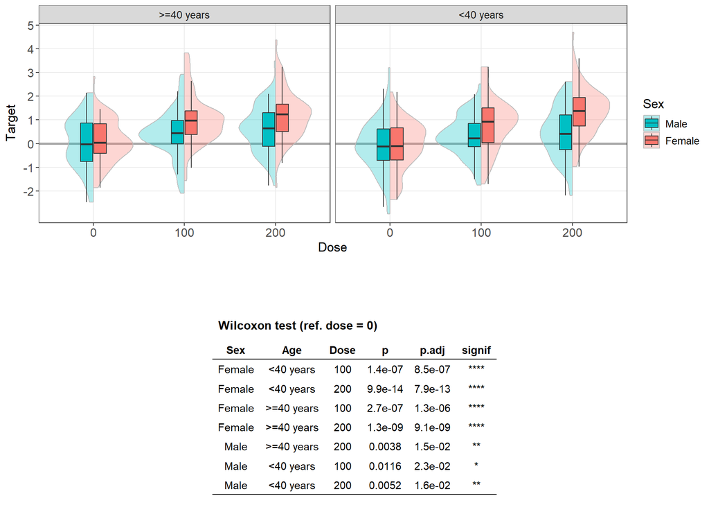

```r
# - Chunk_4a                                                 - #
# - Requires R-libraries and object exampleData (set-up)     - #
# - Requires object geom_split_violin (chunk: splitViolins)  - #

# Generate a table of significant differences (Wilcoxon test)

sign_test <- compare_means(
  data = exampleData,
  target ~ dose,
  group.by = c("sex", "age"),
  ref.group = "0",
  ) %>%
  filter (
    !group1 == "100" &
    !p.signif == "ns"  ) %>%
  select("sex", "age", "group2", "p.format", "p.adj", "p.signif")  %>%
  set_names(
    "Sex", "Age", "Dose", "p", "p.adj", "signif") %>%
  ggtexttable(
    rows = NULL,
    theme = ttheme("light")
    ) %>%
  tab_add_title(
    text = "Wilcoxon test (ref. dose = 0)",
    face = "bold", size = 12,
    )


# Generate split violin plot and insert the Wilcoxon test table

ggarrange(

exampleData %>%
  group_by(bmi, age, race, sex, type) %>%
  select( dose, target) %>%
  ggplot(
    aes(
      x= factor(
        dose,
        levels = c("0", "100", "200")
        ),
      y = target,
# Order low > high responders
    fill =
      factor(
        sex,
        levels = c("Male", "Female") )
        )
      ) +
# Color red for patient variable value with higher response
    scale_fill_hue( direction = -1) +
    geom_hline(
      yintercept = 0,
      color = "darkgrey",
      linewidth = 1.1
      ) +
    geom_split_violin(
      width = 1,
      alpha = 0.3,
      color = "grey") +
    geom_boxplot(
        width = 0.3,
        outlier.shape = NA) +
# Order facets low > high responders
    facet_grid(.
      ~ factor(
        age,
        levels = c(">=40 years", "<40 years")
        )
      ) +
    theme_bw() +
    theme(
      text=element_text( size = 13),
      axis.text = element_text( size = 12),
      ) +
    scale_y_continuous(
      breaks = c(-2: 5),
      minor_breaks = NULL
      ) +
    labs(
      x = "Dose",
      y = "Target",
      fill = "Sex",
      size = 12,
      hjust = -15
      ),

# Add space between plot and table
NULL,

sign_test,

ncol = 1, nrow = 3,
heights = c(2, 0.1, 2),
widths = c(0.2, 1, 1),
align = "h"
)
```

#### 5.2. Dose vs. target values in patients stratified by sex and type of disease

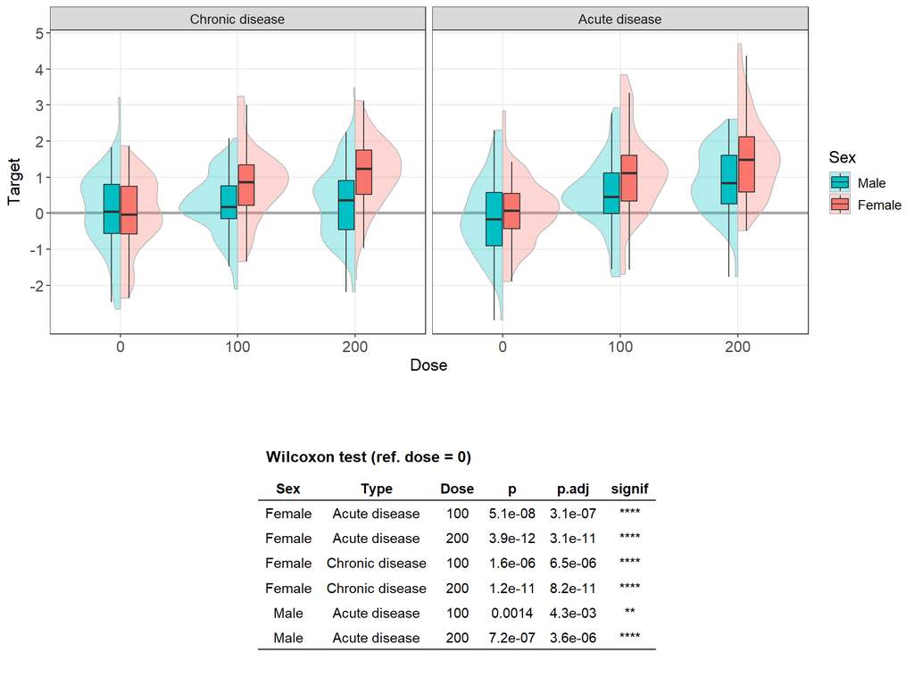

```r
# - Chunk_4b                                                 - #
# - Requires R-libraries and object exampleData (set-up)     - #
# - Requires object geom_split_violin (chunk: splitViolins)  - #

# Generate a table of significant differences (Wilcoxon test)

sign_test <- compare_means(
  data = exampleData,
  target ~ dose,
  group.by = c("sex", "type"),
  ref.group = "0",
  ) %>%
  filter (
    !group1 == "100" &
    !p.signif == "ns"  ) %>%
  select("sex", "type", "group2", "p.format", "p.adj", "p.signif")  %>%
  set_names(
    "Sex", "Type", "Dose", "p", "p.adj", "signif") %>%
  ggtexttable(
    rows = NULL,
    theme = ttheme("light")
    ) %>%
  tab_add_title(
    text = "Wilcoxon test (ref. dose = 0)",
    face = "bold", size = 12,
    )


# Generate split violin plot and insert the Wilcoxon test table

ggarrange(

exampleData %>%
  group_by(bmi, age, race, sex, type) %>%
  select( dose, target) %>%
  ggplot(
    aes(
      x= factor(
        dose,
        levels = c("0", "100", "200")
        ),
      y = target,
# Order low > high responders
    fill =
      factor(
        sex,
        levels = c("Male", "Female") )
        )
      ) +
# Color red for patient variable value with higher response
    scale_fill_hue( direction = -1) +
    geom_hline(
      yintercept = 0,
      color = "darkgrey",
      linewidth = 1.1
      ) +
    geom_split_violin(
      width = 1,
      alpha = 0.3,
      color = "grey") +
    geom_boxplot(
        width = 0.3,
        outlier.shape = NA) +
 # Order facets low > high responders
    facet_grid(.
      ~ factor(
        type,
        levels = c("Chronic disease", "Acute disease")
        )
      ) +
    theme_bw() +
    theme(
      text=element_text( size = 13),
      axis.text = element_text( size = 12),
      ) +
    scale_y_continuous(
      breaks = c(-2: 5),
      minor_breaks = NULL
      ) +
    labs(
      x = "Dose",
      y = "Target",
      fill = "Sex",
      size = 12,
      hjust = -15
      ),

# Add space between plot and table
NULL,

sign_test,

ncol = 1, nrow = 3,
heights = c(2, 0.1, 1.5),
widths = c(0.2, 1, 1),
align = "h"
)
```